# Differential gene expression : microarray VS RNAseq

# 1 Context

## 1.1 Why ?

In order to add a way to handle microarray data in Moomin, we first need to check if both differential gene expressions have similar distributions. Moomin uses a bayesian method to compute the LogFC : EBseq. The method that we are investigating is Cyber-t : its also a bayesian method, but for microarrays. If results between those two are significantly close, cyber-t method can be added in Moomin.

- [x] Cyber-t logFC
- [x] EBseq logFC
- [x] statistical tests (spearman $\rho$ and R-squared)
- [x] Interpretations
- [x] Integration in Moomin
- [ ] Flux analysis comparison in Moomin

## 1.2 The dataset

We found a dataset from the paper [“*Escherichia coli* O157:H7 transcriptome datasets for comparison of RNA-seq and microarray platforms”](https://www.sciencedirect.com/science/article/pii/S2352340918315294?via%3Dihub) that has both RNAseq data and microarray data, for the same organism, with the same condition between samples. (With or without spinach) A very-well organized git repo can be found at : https://github.com/TheMicroGirl/SakaiRNASeq/

# 2 Differential expression analysis with microarray data and Cyber-t

## 2.1 Reading raw data

Raw data consist of 6 TSV files : 2 conditions and 3 replicates each.

Conditions are :

- Leaf lysate
- Minimal media

Limma functions are used here to extract relevant field.

## 2.2 Probes filtering

Keeping only probes that are 10% brighter than negative probes.

```r
neg95 <- apply(microarrayData$E[microarrayData$genes$ControlType==-1,],2,function(x) quantile(x,p=0.95)) #95 percentile of negative probes
cutoff <- matrix(1.1*neg95,nrow(microarrayData),ncol(microarrayData),byrow=TRUE) # keep probes that are 10% brighter than the negative probes
filtered <- rowSums(microarrayData$E > cutoff) >= 3
noNegData <- microarrayData[microarrayData$genes$ControlType==0 & filtered,]
```

## 2.3 Data processing

Rearranging data in a way cyber-t can use.

```r
df <- as.data.frame(noNegData$E)
df <- cbind(noNegData$genes$SystematicName,df)
df <- aggregate(df[,2:7], list(df$`noNegData$genes$SystematicName`), median) # Merging duplicates and keeping median values
colnames(df) <- c("gene_id", "C1", "C2", "C3", "E1", "E2", "E3" )
df <- df[c("gene_id", "E1", "E2", "E3", "C1", "C2", "C3")] # Rearranging df so our values are in the same order than RNAseq data
df <- format(df,  scientific = TRUE)
write.table(df, file="Microarray/microarray_data/processed_data/processed_MA_results.txt", col.names=FALSE, row.names=FALSE, sep =",", quote = FALSE)
```

## 2.4 Call of Cyber-t “bayesT” function

Cyber-t is a method that compute a PPDE and LogFC for probes that got change in intensity (AKA differentially expressed genes). Due to the large number of gene studied, we use ‘winSize = 101’ following cyber-t manual. ‘bayes’ parameter is set to ‘1’ as we want to use a bayesian method.

```r
dataFile<-read.table("Microarray/microarray_data/processed_data/processed_MA_results.txt",sep=",", header = TRUE, row.names = 1)
cyber_t_results <- bayesT(dataFile,numC=3,numE=3,ppde=1, bayes=1, winSize=101, conf=4)
logFC <- log(cyber_t_results$meanE / cyber_t_results$meanC)
```

## 2.5 Writing cyber-t results

Output genes matched with their logFC and PPDE.

```r
cyber_t_output <- data.frame(rownames(cyber_t_results), cyber_t_results$ppde.p, cyber_t_results$fold)
cyber_t_output <- data.frame(rownames(cyber_t_results), cyber_t_results$ppde.p, logFC)
cyber_t_output <- cyber_t_output[order(cyber_t_output$cyber_t_results.ppde.p, decreasing=TRUE), ]
write.table(cyber_t_output, file="Microarray/results/cyber_t_results.txt", quote = FALSE, row.names = FALSE, col.names = FALSE)
```

## 2.6 Building reference table for later

Building a table that matches systematic gene names and probe names.

# 3 Differential expression analysis with RNAseq data and EBseq

## 3.1 Processing Raw data

Raw data can be found here : https://www.ebi.ac.uk/arrayexpress/experiments/E-MTAB-7441/samples/

They were generated using these tools :

1. **Cutadapt** : Trimming adaptors
2. **FastQC** : Quality check
3. **Bowtie2** : Indexing with reference genome
4. **FeatureCounts** : Counting with annotation

They consist of 6 pairs of fastq file (paired-end RNAseq) : 3 replicates per conditions.

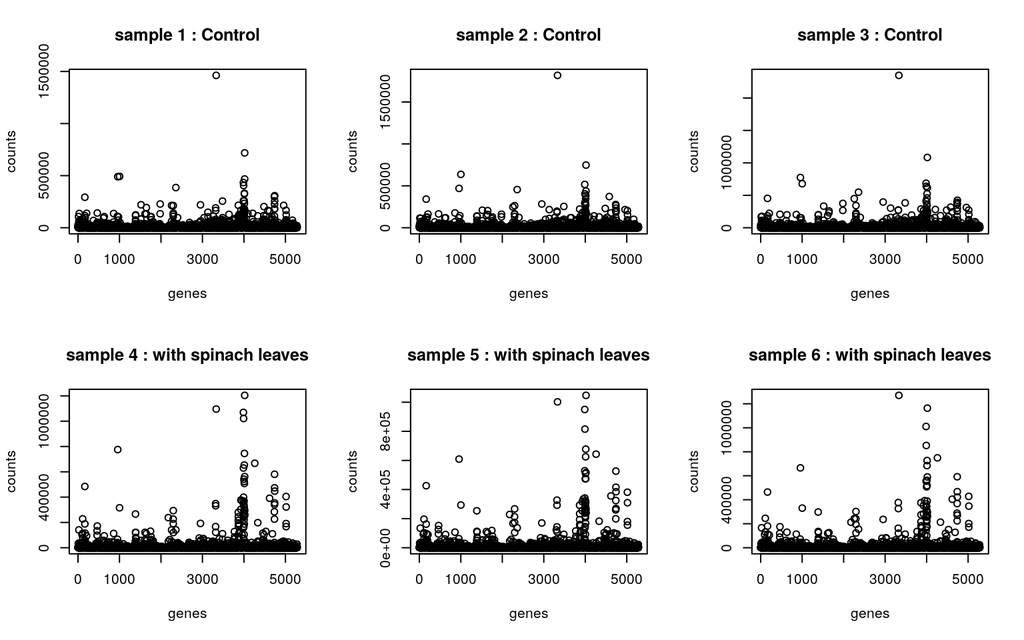

## 3.2 EBseq call : using ‘EBTest’ and ‘GetDEResults’ functions

```
Removing transcripts with 100 th quantile < = 0
5257 transcripts will be tested
```

## 3.3 Checking EBseq results quality

### 3.3.1 check convergence

```
       iter4        iter5
0.0003866783 0.0003898792
```

```
       iter4        iter5
0.0011781582 0.0009537907
```

```
      iter4       iter5
0.004447618 0.001030693
```

### 3.3.2 check model fitness

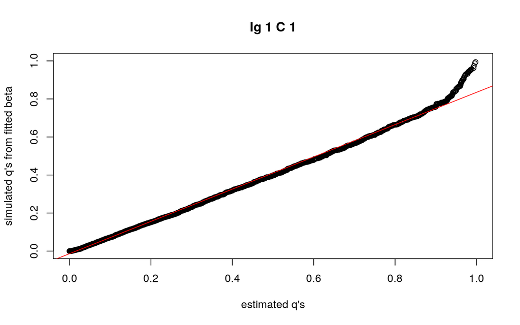

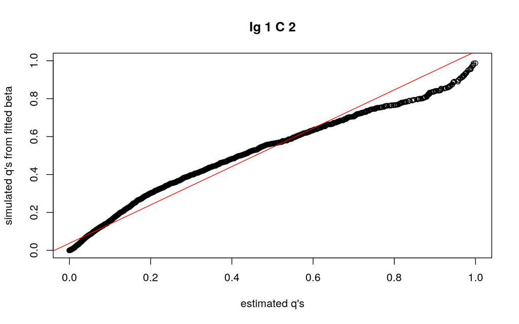

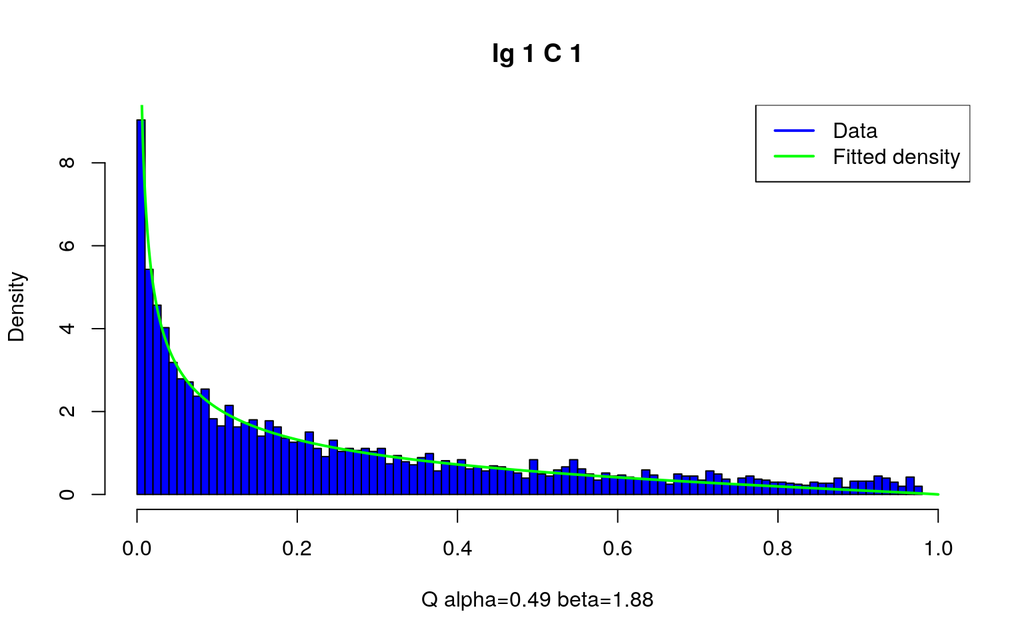

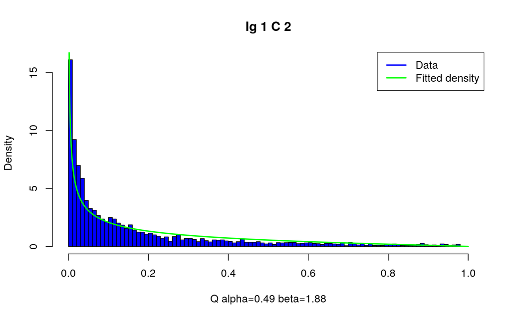

## 3.4 Writing results table

# 4 Merging RNAseq and Microarray data

## 4.1 Import data from our bayesian methods

### 4.1.1 Import Cyber-t results for microarray

|  | gene_id | cyber_t_PPDE | cyber_t_logFC |
| --- | --- | --- | --- |
| 1 | b2686 | 0.9999883 | 2.025996 |
| 2 | c_3997 | 0.9999855 | 2.801059 |
| 3 | b3238 | 0.9999845 | 3.264353 |
| 4 | b2685 | 0.9999839 | 2.001171 |
| 5 | b1598 | 0.9999808 | 2.195407 |
| 6 | ECs1711 | 0.9999802 | 1.673966 |

### 4.1.2 Import EBseq results for RNAseq

|  | gene_id | EBseq_PPDE | EBseq_logFC |
| --- | --- | --- | --- |
| 1 | ECp021.1n | 2.360508e-18 | 0.43173080 |
| 2 | ECp023 | 1.577547e-19 | 0.11636311 |
| 3 | ECp025.2n | 3.115553e-08 | -0.27785660 |
| 4 | ECp042 | 7.940136e-19 | 0.35872964 |
| 5 | ECp054 | 1.365977e-01 | 0.07049246 |
| 6 | ECp070 | 3.304690e-01 | 0.20685597 |

## 4.2 Repair name discrepancies between RNAseq data and microarray data

## 4.3 Import data from the paper for comparison

### 4.3.1 Import Limma results for microarray

### 4.3.2 Import EdgeR results for RNAseq

## 4.4 Merging all results in one big df

## 4.5 Filtering out unsignificant values

```
[1] 7950    9
```

```
[1] 2031    9
```

|  | gene_id | cyber_t_logFC | EB_logFC | limma_logFC | EdgeR_logFC | cyber_t_PPDE | EBseq_PPDE | limma_Pval | EdgeR_Pval |
| --- | --- | --- | --- | --- | --- | --- | --- | --- | --- |
| 1 | ABE-0012311 | -0.9971959529 | -1.0735117 | -1.3173815 | -1.5361324 | 0.9972169258389149693044828381971456110477448 | 1.0000000 | 1.848835e-04 | 7.498056e-07 |
| 8 | ABE-0285088 | -0.6916915762 | 0.7400970 | -0.8593656 | 1.1141873 | 0.9797732520066569916750154334295075386762619 | 1.0000000 | 2.902252e-03 | 1.204323e-04 |
| 15 | b0002 | -2.1800027667 | -1.9234034 | -2.8681432 | -2.7517294 | 0.9822053921637849960291077877627685666084290 | 1.0000000 | 3.141009e-05 | 1.628564e-07 |
| 16 | b0003 | -2.0575813912 | -1.7452678 | -2.7475096 | -2.5053480 | 0.9908348385864019780555622674000915139913559 | 1.0000000 | 1.564815e-05 | 1.543156e-08 |
| 17 | b0004 | -1.7447647021 | -1.8667413 | -2.2791961 | -2.6889631 | 0.9936808965424159811874460501712746918201447 | 1.0000000 | 2.097069e-05 | 3.096478e-08 |
| 18 | b0005 | -1.0611237488 | -0.4107800 | -1.2323106 | -0.5837186 | 0.9734878564661529898316416620218660682439804 | 0.9990838 | 7.502311e-04 | 4.534703e-03 |
| 26 | b0014 | -0.7657137662 | -0.9708238 | -0.9098699 | -1.3881382 | 0.9611313913654779828021901266765780746936798 | 1.0000000 | 2.465733e-03 | 1.037560e-07 |
| 39 | b0023 | 0.8913326696 | 0.9508685 | 1.4229363 | 1.3841498 | 0.9990550383225600405978639173554256558418274 | 1.0000000 | 2.159803e-04 | 7.098074e-07 |
| 47 | b0032 | -3.6588066141 | -3.7533713 | -5.1655589 | -5.4014710 | 0.9969048362363089887949740841577295213937759 | 1.0000000 | 4.891222e-07 | 6.343161e-10 |
| 48 | b0033 | -3.7587658368 | -3.6930659 | -5.3594124 | -5.3217117 | 0.9981889981821819857188415880955290049314499 | 1.0000000 | 7.479033e-07 | 2.972176e-10 |

[output cut: 65 more lines]

```
[1] 1938    9
```

## 4.6 Filtering out missing values

```
[1] 7950    9
```

|  | gene_id | cyber_t_logFC | EB_logFC | limma_logFC | EdgeR_logFC | cyber_t_PPDE | EBseq_PPDE | limma_Pval | EdgeR_Pval |
| --- | --- | --- | --- | --- | --- | --- | --- | --- | --- |
| 1 | ABE-0012311 | -0.9971959529 | -1.073511699 | -1.317381483 | -1.536132411 | 0.9972169258389149693044828381971456110477448 | 1.000000e+00 | 1.848835e-04 | 7.498056e-07 |
| 2 | ABE-0047279 | -0.0076489173 | 0.503290837 | 0.204088413 | 0.739150702 | 0.0000000000000001455882639731950114238526492 | 1.000000e+00 | 2.569779e-01 | 6.451872e-04 |
| 3 | ABE-0285051 | -0.2812241876 | 0.506993459 | -0.163954243 | 0.742550368 | 0.1697267533142960138636823330671177245676517 | 1.000000e+00 | 4.757118e-01 | 6.577730e-05 |
| 5 | ABE-0285062 | -0.0931688514 | 0.273208686 | -0.074385872 | 0.448343500 | 0.0002280101392921639921317761290353587355639 | 7.635757e-18 | 7.181980e-01 | 7.481277e-02 |
| 6 | ABE-0285077 | 0.2634816032 | 0.469481124 | 0.607384368 | 0.688097182 | 0.6134827090381950176478653702361043542623520 | 1.000000e+00 | 1.634255e-02 | 7.294266e-04 |
| 7 | ABE-0285085 | 0.3166696093 | 0.452864477 | 0.714225333 | 0.602504200 | 0.6720949587750200127089783563860692083835602 | 1.000000e+00 | 4.243852e-03 | 3.317603e-03 |
| 8 | ABE-0285088 | -0.6916915762 | 0.740096980 | -0.859365617 | 1.114187328 | 0.9797732520066569916750154334295075386762619 | 1.000000e+00 | 2.902252e-03 | 1.204323e-04 |
| 9 | ABH-0244047 | 0.3131077936 | 0.224245695 | 0.758066600 | 0.230374700 | 0.6488795065786240323646438810101244598627090 | 6.086613e-01 | 1.383648e-02 | 2.293380e-01 |
| 10 | ABH-0285131 | 0.2350561197 | -0.632455492 | 0.577273729 | -0.956830600 | 0.5357654831747320489654384800815023481845856 | 9.999903e-01 | 1.280166e-02 | 4.435337e-03 |
| 12 | ABH-0285234 | 0.3419517024 | 0.333476093 | 0.715813525 | 0.496825400 | 0.6564445339023909919973220894462428987026215 | 3.757212e-01 | 4.166184e-02 | 1.808060e-01 |

[output cut: 65 more lines]

```
[1] 7030    9
```

# 5 Results comparison

## 5.1 Overlap

|  | gene_id | cyber_t_logFC | EB_logFC | limma_logFC | EdgeR_logFC | cyber_t_PPDE | EBseq_PPDE | limma_Pval | EdgeR_Pval |
| --- | --- | --- | --- | --- | --- | --- | --- | --- | --- |
| 1 | ABE-0012311 | -0.9971959529 | -1.073511699 | -1.317381483 | -1.536132411 | 0.9972169258389149693044828381971456110477448 | 1.000000e+00 | 1.848835e-04 | 7.498056e-07 |
| 2 | ABE-0047279 | -0.0076489173 | 0.503290837 | 0.204088413 | 0.739150702 | 0.0000000000000001455882639731950114238526492 | 1.000000e+00 | 2.569779e-01 | 6.451872e-04 |
| 3 | ABE-0285051 | -0.2812241876 | 0.506993459 | -0.163954243 | 0.742550368 | 0.1697267533142960138636823330671177245676517 | 1.000000e+00 | 4.757118e-01 | 6.577730e-05 |
| 5 | ABE-0285062 | -0.0931688514 | 0.273208686 | -0.074385872 | 0.448343500 | 0.0002280101392921639921317761290353587355639 | 7.635757e-18 | 7.181980e-01 | 7.481277e-02 |
| 6 | ABE-0285077 | 0.2634816032 | 0.469481124 | 0.607384368 | 0.688097182 | 0.6134827090381950176478653702361043542623520 | 1.000000e+00 | 1.634255e-02 | 7.294266e-04 |
| 7 | ABE-0285085 | 0.3166696093 | 0.452864477 | 0.714225333 | 0.602504200 | 0.6720949587750200127089783563860692083835602 | 1.000000e+00 | 4.243852e-03 | 3.317603e-03 |
| 8 | ABE-0285088 | -0.6916915762 | 0.740096980 | -0.859365617 | 1.114187328 | 0.9797732520066569916750154334295075386762619 | 1.000000e+00 | 2.902252e-03 | 1.204323e-04 |
| 9 | ABH-0244047 | 0.3131077936 | 0.224245695 | 0.758066600 | 0.230374700 | 0.6488795065786240323646438810101244598627090 | 6.086613e-01 | 1.383648e-02 | 2.293380e-01 |
| 10 | ABH-0285131 | 0.2350561197 | -0.632455492 | 0.577273729 | -0.956830600 | 0.5357654831747320489654384800815023481845856 | 9.999903e-01 | 1.280166e-02 | 4.435337e-03 |
| 12 | ABH-0285234 | 0.3419517024 | 0.333476093 | 0.715813525 | 0.496825400 | 0.6564445339023909919973220894462428987026215 | 3.757212e-01 | 4.166184e-02 | 1.808060e-01 |

[output cut: 65 more lines]

## 5.2 Limma Vs EdgeR

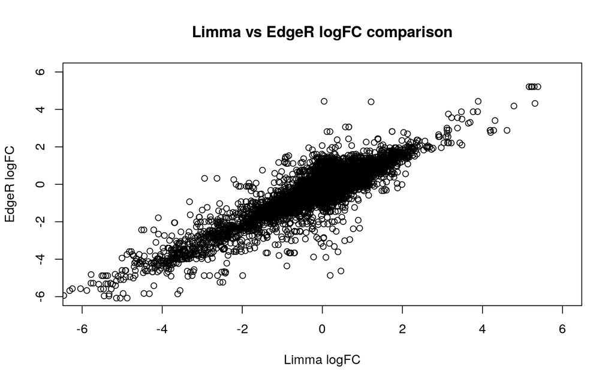

## 5.3 EBseq Vs EdgeR

```
[1] 7030
```

```
[1] 7030
```

```
[1] 7030
```

```
[1] 7030
```

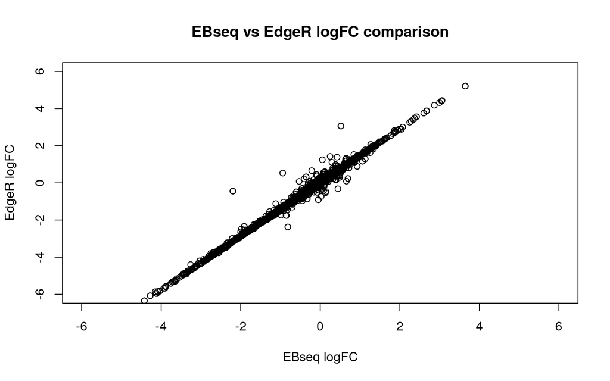

## 5.4 Cyber-t Vs Limma

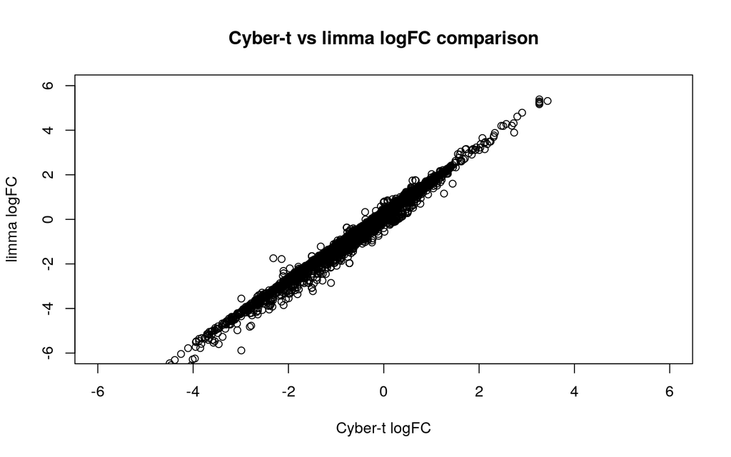

## 5.5 Cyber-t Vs EBseq

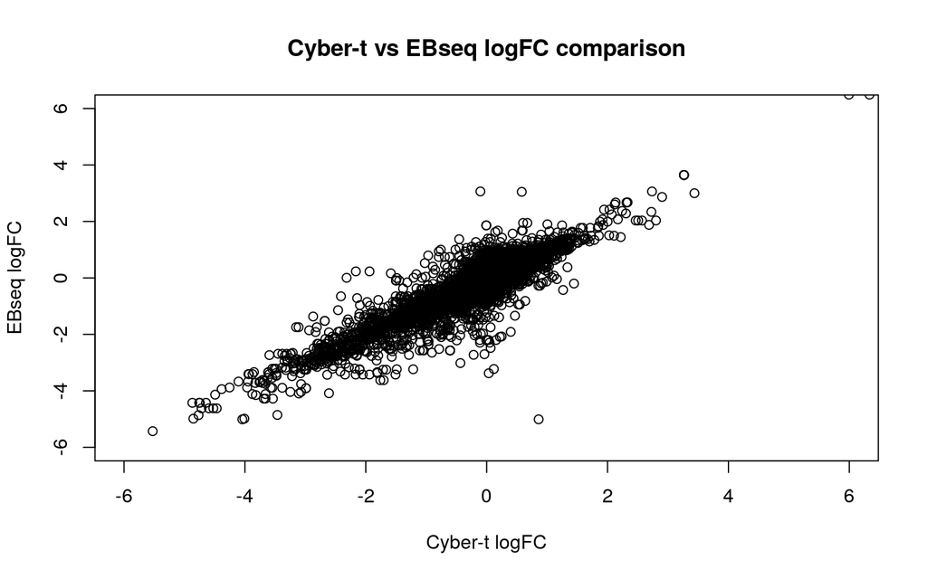

## 5.6 Table of results

|  | Spearman : rho | R² |
| --- | --- | --- |
| Limma / EdgeR | 0.8154084 | 0.8144400 |
| EBseq / EdgeR | 0.9935492 | 0.9924891 |
| Cyber-t / Limma | 0.9865364 | 0.9852747 |
| Cyber-T / EBseq | 0.8266906 | 0.8124529 |
| limma / FC (above threshold) | 0.9441733 | 0.9289999 |
| Cyber-t / EBseq (above threshold) | 0.9361072 | 0.9203020 |

## 5.7 Volcano plots

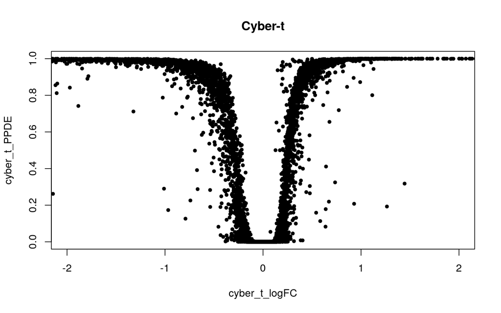

```r
with(summary, plot(cyber_t_logFC, cyber_t_PPDE, pch=20, main="Cyber-t", xlim=c(-2,2)))
```

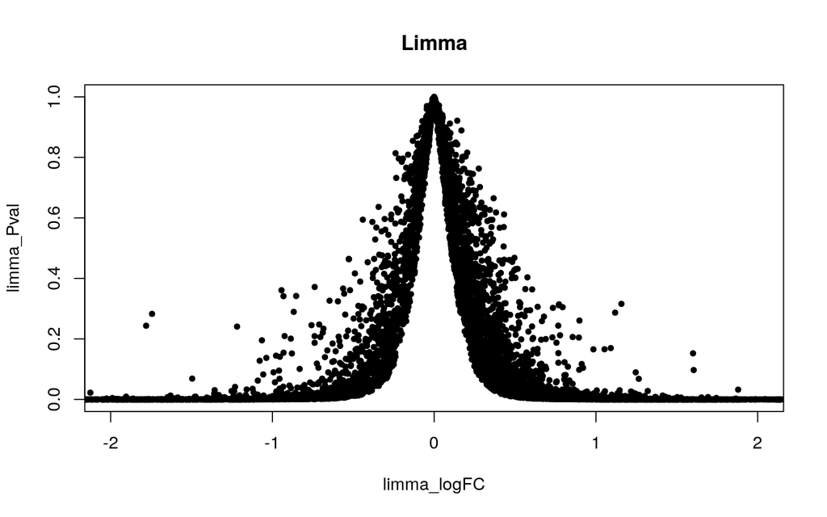

```r
with(summary, plot(limma_logFC, limma_Pval, pch=20, main="Limma",  xlim=c(-2,2)))
```

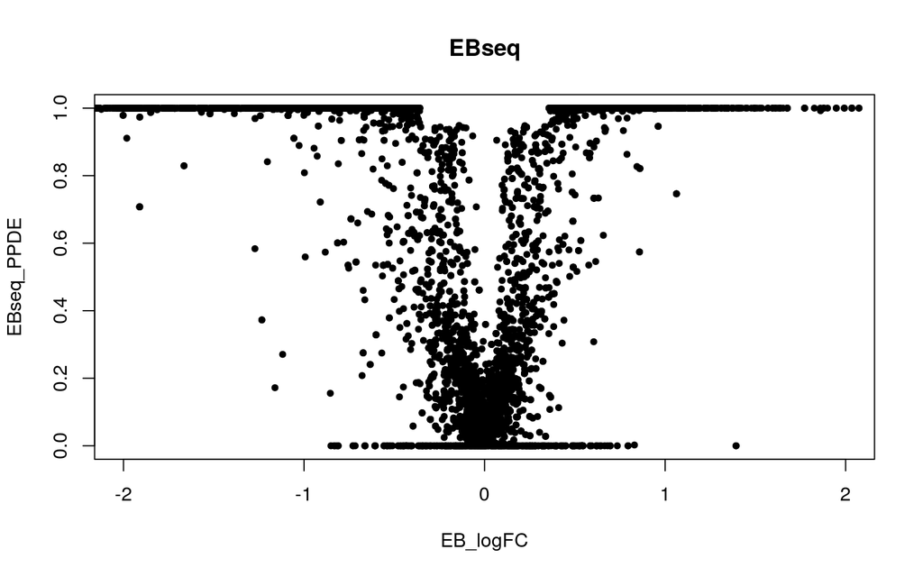

```r
with(summary, plot(EB_logFC, EBseq_PPDE, pch=20, main="EBseq",  xlim=c(-2,2)))
```

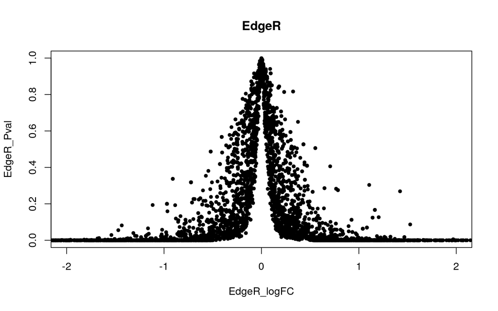

```r
with(summary, plot(EdgeR_logFC, EdgeR_Pval, pch=20, main="EdgeR",  xlim=c(-2,2)))
```

# 6 Format and export data for Moomin input

# 7 Compare Moomin results from EBSeq or Cyber-T

```
[1] 2093
```

```
[1] 490   3
```

```
[1] 369   3
```

```
[1] 35  3
```

```
      rho
0.7871266
```

[figure not shown]

2019-05-27